# Git under the hood

### Or: how to stop worrying and love the rebase

[figure not shown]

*"If that doesn't fix it, git.txt contains the phone number of a friend of mine who understands git. Just wait through a few minutes of 'It's really pretty simple, just think of branches as...' and eventually you'll learn the commands that will fix everything."*

## What is Git?

Git is a **Distributed Version Control System (VCS)**

- **Version Control**: Keep track of changes and version
  - I want to go back to the non-broken version!
  - Who made which changes?
- **Distributed**: No central truth
  - Everybody has complete history
  - Personal VC possible: keep track of private changes without sharing with the world
- **Team Work**: Tool for combining individual work

# The Commit

- Commit = a snapshot of the state of your project
- Series of commits track full history and changes
- Records *who* did *what* , *when* and *why*
- Allows to go back in time and recover old versions

## Commit Steps (theory)

Creating a commit in Git follows these steps:

1. Make changes in working directory
2. Tell Git which changes to record (*staging*)
3. Tell Git to make commit
4. Write commit message

## Commit Steps (practice)

```bash
# 1. Make changes
echo "I like cats" > foo.txt
git status
```

```
On branch master

No commits yet

Untracked files:
  (use "git add <file>..." to include in what will be committed)

	foo.txt

nothing added to commit but untracked files present (use "git add" to track)
```

## Commit Steps (practice)

```bash
# 2. Staging
git add foo.txt
git status
```

```
On branch master

No commits yet

Changes to be committed:
  (use "git rm --cached <file>..." to unstage)

	new file:   foo.txt
```

## Commit Steps (practice)

```bash
# 3. Start commit
# 4. Write commit message
git commit -m "My first commit!"
```

```
[master (root-commit) 087f3ac] My first commit!
 1 file changed, 1 insertion(+)
 create mode 100644 foo.txt
```

```bash
git status
```

```
On branch master
nothing to commit, working tree clean
```

# Onwards

```bash
sed -e 's/cats/dogs/' -i '' foo.txt
git status
```

```
sed: can't read : No such file or directory
On branch master
Changes not staged for commit:
  (use "git add <file>..." to update what will be committed)
  (use "git checkout -- <file>..." to discard changes in working directory)

	modified:   foo.txt

no changes added to commit (use "git add" and/or "git commit -a")
```

# Onwards

```bash
git diff
```

```
diff --git a/foo.txt b/foo.txt
index f9504d1..af307d5 100644
--- a/foo.txt
+++ b/foo.txt
@@ -1 +1 @@
-I like cats
+I like dogs
```

# Onwards

```bash
git add foo.txt
git commit -m 'Canines rule'
```

```
[master 9f2bdb3] Canines rule
 1 file changed, 1 insertion(+), 1 deletion(-)
```

```bash
git log
```

```
commit 9f2bdb3a9a5ba1cd6518f1bbc2e1c777ad3c512f (HEAD -> master)
Author: Sander van Dijk <sander@parkopedia.com>
Date:   Fri Jan 10 20:31:19 2020 +0000

    Canines rule

commit 087f3ac256dcc6fa618956033ff11e8f5e8a8e6d
Author: Sander van Dijk <sander@parkopedia.com>
Date:   Fri Jan 10 20:31:15 2020 +0000

    My first commit!
```

# What is that commit hash?

```bash
echo "Monitor lizard" | git hash-object -w --stdin
```

```
f54a8a3bb1ad85ce7d9f00954081f269ccd7ec82
```

# Git tracks everything with hashes

| *Type* | *Contents* | *Identified by* |  |
| --- | --- | --- | --- |
| **Blob** | File contents | Hash of the file's bytes |  |
| **Tree** | Association of names & folers with blobs | Hash of the file tree structure |  |
| **Commit** | Metadata for author, commit, timestamp(s), message | Hash of the commit structure |  |

# Git tracks everything with hashes

[figure not shown]

To Remember:

## Any difference between commits 🠚 different hashes

# Commit contents

```bash
git log --all --decorate --oneline --graph
```

```
* 9f2bdb3 (HEAD -> master) Canines rule
* 087f3ac My first commit!
```

```bash
git cat-file -p 087f3ac
```

```
tree 010e768eba617799341444d97cf96e7b0cb629ea
author Sander van Dijk <sander@parkopedia.com> 1578688275 +0000
committer Sander van Dijk <sander@parkopedia.com> 1578688275 +0000

My first commit!
```

# Lineage

## Lineage

Git's history forms a **Directed Acyclic Graph (DAG)**

- All commits point to their parent(s)
- No way to follow arrows back to start

Our graph after the 2 commits:

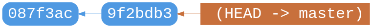

```bash
gitloggraph
```

## I was told there'd be branches...

Conceptually a branch is

- a separate line of development
- all commits from some branching point

In practice a branch is

- just a label pointing to a commit
- **not** a set of commits, but ...
- *implicitely* made up of all commits reachable from reference

## What about tags?

- Tags label commits to make them special/easier to find
- Tags are fixed to a single commit
- Branch label follows new commits/`HEAD`

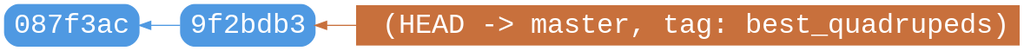

```bash
git tag best_quadrupeds && gitloggraph
```

```
[master a8cd530] Some commits are more equal
 1 file changed, 1 insertion(+)
 create mode 100644 bar.txt
```

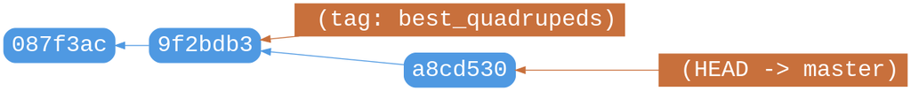

```bash
echo "Four legs good, two legs better" > bar.txt
git add bar.txt && git commit -m "Some commits are more equal" && gitloggraph
```

## Let's branch

```
Note: checking out 'best_quadrupeds'.

You are in 'detached HEAD' state. You can look around, make experimental
changes and commit them, and you can discard any commits you make in this
state without impacting any branches by performing another checkout.

If you want to create a new branch to retain commits you create, you may
do so (now or later) by using -b with the checkout command again. Example:

  git checkout -b <new-branch-name>

HEAD is now at 9f2bdb3 Canines rule
```

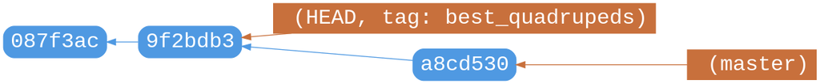

```bash
git checkout best_quadrupeds && gitloggraph
```

## Let's branch

```
Switched to a new branch 'water_quads'
```

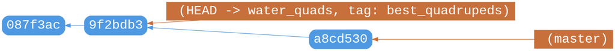

```bash
# `checkout -b x` is shorthand for `git branch x && git checkout x`
git checkout -b water_quads && gitloggraph
```

```
[water_quads 644c313] Shells are cool
 1 file changed, 1 insertion(+), 1 deletion(-)
```

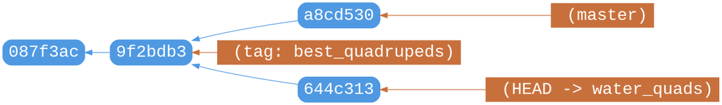

```bash
sed -e 's/dogs/turtles/' -i foo.txt && git commit -a -m 'Shells are cool' && gitloggraph
```

## Merging

```
Switched to branch 'master'
Merge made by the 'recursive' strategy.
 foo.txt | 2 +-
 1 file changed, 1 insertion(+), 1 deletion(-)
```

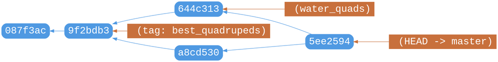

```bash
git checkout master
git merge water_quads -m "Merging 'water_quads' into master" && gitloggraph
```

```bash
ls && cat foo.txt
```

```
bar.txt  foo.txt
I like turtles
```

## Rebasing

```
HEAD is now at a8cd530 Some commits are more equal
Switched to branch 'water_quads'
```

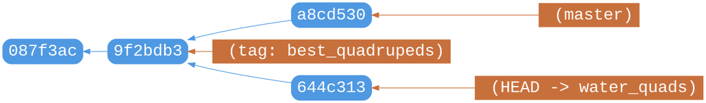

```bash
git reset --hard HEAD@{1} && git checkout water_quads && gitloggraph
```

```
First, rewinding head to replay your work on top of it...
Applying: Shells are cool
```

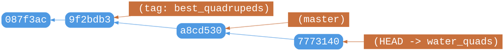

```bash
git rebase master && gitloggraph
```

## Merge or Rebase?

Why merge:

- Log shows history as it happened
- List of merge commits are summary (not 1000x 'fixed typo/whitespace'...)

Why rebase:

- Many parallel branches = chaotic DAG
- Conflicts resolved at commit where they happened
- Rewrite history to reflect higher level conceptual steps rather than just code changes

**Per team decision** but also IMHO **per branch**

# Undoing

## Oops...

> "I won't commit/branch/push, I'm afraid I will break something"

> Git novice

Reality: *very* hard to completely screw up

## Git never forgets†

### Git never overwrites

Rewriting history (rebasing, appending commits, etc) creates *new, independent commits*

### Git doesn't delete †

Old commits are there, but just not visible when unreachable

*Reachability*: a commit is *reachable* when there is a directed path from a branch reference to that commit

## Finding lost commits

```bash
git fsck --lost-found | tee fsck.out
```

```
Checking object directories: 100% (256/256), done.
dangling commit 5ee2594cc5949c529b823687dbabc98d950ef98c
dangling blob f54a8a3bb1ad85ce7d9f00954081f269ccd7ec82
```

```bash
# Show content of dangling commit
grep 'dangling commit' < fsck.out | cut -d ' ' -f 3 | tee lost-commit | xargs git cat-file -p
```

```
tree 040e3a8909a5a77c8bb63ab3a59afc0975d7c3c6
parent a8cd5306ee031dedbc85a45b537e57c4dece90c6
parent 644c313e33431bfda50f76f48fe003b7b0d49424
author Sander van Dijk <sander@parkopedia.com> 1578688335 +0000
committer Sander van Dijk <sander@parkopedia.com> 1578688335 +0000

Merging 'water_quads' into master
```

## Recover!

```
Switched to a new branch 'return-of-the-merge'
```

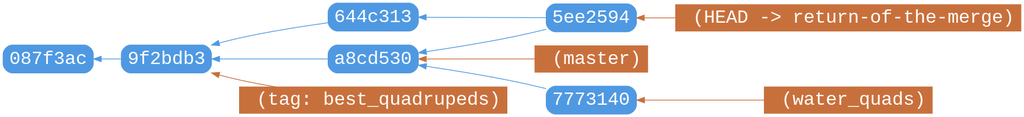

```bash
git checkout -b return-of-the-merge $(cat lost-commit) && gitloggraph
```

## The reflog

Keeps track of all the commits a reference pointed at.

```bash
git reflog -n 10
```

```
5ee2594 (HEAD -> return-of-the-merge) HEAD@{0}: checkout: moving from water_quads to return-of-the-merge
7773140 (water_quads) HEAD@{1}: rebase finished: returning to refs/heads/water_quads
7773140 (water_quads) HEAD@{2}: rebase: Shells are cool
a8cd530 (master) HEAD@{3}: rebase: checkout master
644c313 HEAD@{4}: checkout: moving from master to water_quads
a8cd530 (master) HEAD@{5}: reset: moving to HEAD@{1}
5ee2594 (HEAD -> return-of-the-merge) HEAD@{6}: merge water_quads: Merge made by the 'recursive' strategy.
a8cd530 (master) HEAD@{7}: checkout: moving from water_quads to master
644c313 HEAD@{8}: commit: Shells are cool
9f2bdb3 (tag: best_quadrupeds) HEAD@{9}: checkout: moving from 9f2bdb3a9a5ba1cd6518f1bbc2e1c777ad3c512f to water_quads
```

## More undoing

- Working changes
- Staging
- Amending commits

But first, tips to make recovery easier:

- *Branch soon and often* - branches are easy to discard
- *Commit often* - can always reorder / squash / discard small changes
- *Communicate* about public branches

## Undoing working changes

```bash
echo "mistake 1" >> foo.txt && echo "mistake 2" >> bar.txt && git status -s -uno
```

```
 M bar.txt
 M foo.txt
```

```bash
# Discard changes to single file
git checkout foo.txt && git status -s -uno
```

```
 M bar.txt
```

```bash
# Discard all changes
git reset --hard && git status -uno
```

```
HEAD is now at 5ee2594 Merging 'water_quads' into master
On branch return-of-the-merge
nothing to commit (use -u to show untracked files)
```

## Undoing staging

```bash
echo "mistake 3" >> foo.txt && git add foo.txt && git status -s -uno
```

```
M  foo.txt
```

```bash
git reset foo.txt
```

```
Unstaged changes after reset:
M	foo.txt
```

## Amending commits

```bash
echo "mistake 3" >> foo.txt && echo "mistake 4" >> bar.txt && git add foo.txt && git commit -m "adding mistake 4"
```

```
[return-of-the-merge 8ebea8e] adding mistake 4
 1 file changed, 2 insertions(+)
```

```bash
# Amending commit message
git commit --amend -m "adding mistake 3"
```

```
[return-of-the-merge 4448a37] adding mistake 3
 Date: Fri Jan 10 20:39:33 2020 +0000
 1 file changed, 2 insertions(+)
```

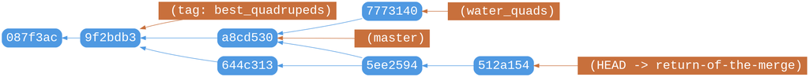

```bash
# adding more changes
git add bar.txt && git commit --amend -m "adding mistakes 3 and 4" > /dev/null
gitloggraph
```

## Revert commits

Create a new commit that does the inverse of another

```bash
git revert --no-edit HEAD
```

```
[return-of-the-merge b1013cd] Revert "adding mistakes 3 and 4"
 Date: Fri Jan 10 20:40:52 2020 +0000
 2 files changed, 3 deletions(-)
```

```bash
git log --oneline -n 3
```

```
b1013cd (HEAD -> return-of-the-merge) Revert "adding mistakes 3 and 4"
512a154 adding mistakes 3 and 4
5ee2594 Merging 'water_quads' into master
```

```bash
git diff HEAD~2
```

This shows that after reverting a commit, the tree is in exactly the same state as 2 commits back, which is what you'd expect.

## Revert commits

Why not reset?

- Can revert any commit, not just last
- Revert already published commits

## † When Git *does* forget

When you tell it to:

- Garbage collect
- Reset unstaged/uncommitted data

[figure not shown]